# Reproducible Research Project 2

# Effect of Weather Events on Personal Health and Property Damage, 1950-2011

## Synopsis

Storms and other severe weather events can cause both public health and economic problems for communities and municipalities. Many severe events can result in fatalities, injuries, and property damage, and preventing such outcomes to the extent possible is a key concern.

This project involves exploring the U.S. National Oceanic and Atmospheric Administration’s (NOAA) storm database. This database tracks characteristics of major storms and weather events in the United States, including when and where they occur, as well as estimates of any fatalities, injuries, and property damage.

## Data Processing

### Loading and preprocessing the data

For the first knitting, read the original file repdata_data_StormData.csv. Create a dataframe with just the columns needed for this analysis and write it out to StormData.csv. Future knittings will check for this file and read it instead of the original. This saves a great deal of time during development because the original file takes a long time to load. Also, it can be convenient to have all of the required data in a smaller file.

```r
if(!file.exists("StormData.csv")){
    data0 <- read.csv("repdata_data_StormData.csv")
    str(data0)
    data <- data0[c("EVTYPE","FATALITIES","INJURIES","PROPDMG","PROPDMGEXP","CROPDMG","CROPDMGEXP")]
    write.csv(data, "StormData.csv")
}else{
    data <- read.csv("StormData.csv")
}
```

### Explore the data

Look at the data with the str commmand and output all unique values of PROPDMGEXP and CROPDMGEXP.

```r
str(data)
```

```
## 'data.frame':    902297 obs. of  8 variables:
##  $ X         : int  1 2 3 4 5 6 7 8 9 10 ...
##  $ EVTYPE    : Factor w/ 985 levels "   HIGH SURF ADVISORY",..: 834 834 834 834 834 834 834 834 834 834 ...
##  $ FATALITIES: int  0 0 0 0 0 0 0 0 1 0 ...
##  $ INJURIES  : int  15 0 2 2 2 6 1 0 14 0 ...
##  $ PROPDMG   : num  25 2.5 25 2.5 2.5 2.5 2.5 2.5 25 25 ...
##  $ PROPDMGEXP: Factor w/ 19 levels "","-","?","+",..: 17 17 17 17 17 17 17 17 17 17 ...
##  $ CROPDMG   : num  0 0 0 0 0 0 0 0 0 0 ...
##  $ CROPDMGEXP: Factor w/ 9 levels "","?","0","2",..: 1 1 1 1 1 1 1 1 1 1 ...
```

```r
unique(data$PROPDMGEXP)
```

```
##  [1] K M   B m + 0 5 6 ? 4 2 3 h 7 H - 1 8
## Levels:  - ? + 0 1 2 3 4 5 6 7 8 B h H K m M
```

```r
unique(data$CROPDMGEXP)
```

```
## [1]   M K m B ? 0 k 2
## Levels:  ? 0 2 B k K m M
```

### Look at 30 most common events

```r
evcount <- aggregate(data$EVTYPE, by=list(data$EVTYPE), FUN=length)
print(evcount[order(-evcount$x),][1:30,])
```

```
##                      Group.1      x
## 244                     HAIL 288661
## 856                TSTM WIND 219940
## 760        THUNDERSTORM WIND  82563
## 834                  TORNADO  60652
## 153              FLASH FLOOD  54277
## 170                    FLOOD  25326
## 786       THUNDERSTORM WINDS  20843
## 359                HIGH WIND  20212
## 464                LIGHTNING  15754
## 310               HEAVY SNOW  15708
## 290               HEAVY RAIN  11723
## 972             WINTER STORM  11433
## 978           WINTER WEATHER   7026
## 216             FUNNEL CLOUD   6839
```

[output cut: 16 more lines]

### Use PROPDMG and PROPDMGEXP to create PROPVALUE

Create multiplier PROPMULT for all unique values of PROPDMGEXP to adjust PROPDMG

```r
data$PROPMULT <- 1
data$PROPMULT[data$PROPDMGEXP == "K"] <- 1000
data$PROPMULT[data$PROPDMGEXP == "M"] <- 1e+06
data$PROPMULT[data$PROPDMGEXP == ""]  <- 1
data$PROPMULT[data$PROPDMGEXP == "B"] <- 1e+09
data$PROPMULT[data$PROPDMGEXP == "m"] <- 1e+06
data$PROPMULT[data$PROPDMGEXP == "+"] <- 1
data$PROPMULT[data$PROPDMGEXP == "0"] <- 1
data$PROPMULT[data$PROPDMGEXP == "5"] <- 1e+05
data$PROPMULT[data$PROPDMGEXP == "6"] <- 1e+06
data$PROPMULT[data$PROPDMGEXP == "?"] <- 0
data$PROPMULT[data$PROPDMGEXP == "4"] <- 10000
data$PROPMULT[data$PROPDMGEXP == "2"] <- 100
data$PROPMULT[data$PROPDMGEXP == "3"] <- 1000
data$PROPMULT[data$PROPDMGEXP == "h"] <- 100
data$PROPMULT[data$PROPDMGEXP == "7"] <- 1e+07
data$PROPMULT[data$PROPDMGEXP == "H"] <- 100
data$PROPMULT[data$PROPDMGEXP == "-"] <- 0
data$PROPMULT[data$PROPDMGEXP == "1"] <- 10
data$PROPMULT[data$PROPDMGEXP == "8"] <- 1e+08

data$PROPVALUE <- data$PROPDMG * data$PROPMULT
```

### Use CROPDMG and CROPDMGEXP to create CROPVALUE

```r
data$CROPMULT <- 1
data$CROPMULT[data$CROPDMGEXP == "M"] <- 1e+06
data$CROPMULT[data$CROPDMGEXP == "K"] <- 1000
data$CROPMULT[data$CROPDMGEXP == "m"] <- 1e+06
data$CROPMULT[data$CROPDMGEXP == "B"] <- 1e+09
data$CROPMULT[data$CROPDMGEXP == "?"] <- 0
data$CROPMULT[data$CROPDMGEXP == "0"] <- 1
data$CROPMULT[data$CROPDMGEXP == "k"] <- 1000
data$CROPMULT[data$CROPDMGEXP == "2"] <- 100
data$CROPMULT[data$CROPDMGEXP == ""] <- 1

data$CROPVALUE <- data$CROPDMG * data$CROPMULT
```

### Aggregate data by event

```r
fatal <- aggregate(FATALITIES ~ EVTYPE, data, FUN = sum)
injury <- aggregate(INJURIES ~ EVTYPE, data, FUN = sum)
propdmg <- aggregate(PROPVALUE ~ EVTYPE, data, FUN = sum)
cropdmg <- aggregate(CROPVALUE ~ EVTYPE, data, FUN = sum)
```

### Plot events with ten highest fatality and ten highest injury counts

As can be seen, tornados have resulted in the highest total fatalities and injury. It would be useful to do some additional cleaning of the data should be done to combine related events. For example, EXCESSIVE HEAT and HEAT are essentially the same, especially when they result in fatalities.

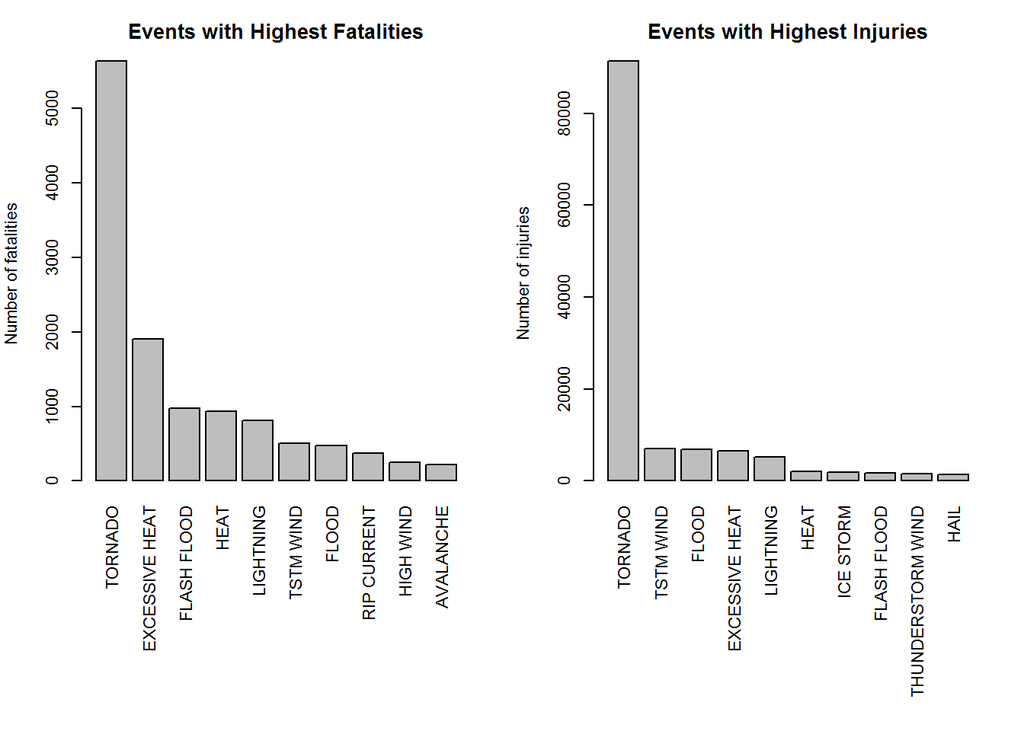

```r
fatal <- fatal[order(-fatal$FATALITIES),][1:10,]
injury <- injury[order(-injury$INJURIES),][1:10,]
par(mfrow = c(1, 2), mar = c(12, 4, 3, 2), mgp = c(3, 1, 0), cex = 0.7)
barplot(fatal$FATALITIES, las = 3, names.arg = fatal$EVTYPE, main = "Events with Highest Fatalities",
        ylab = "Number of fatalities")
barplot(injury$INJURIES, las = 3, names.arg = injury$EVTYPE, main = "Events with Highest Injuries",
        ylab = "Number of injuries")
```

### Plot events with ten highest damages in property and crop damage

As can be seen, flooding appears to have caused the highest property damage and drought has caused the highest crop damage. As before, it would be useful to combine similar events.

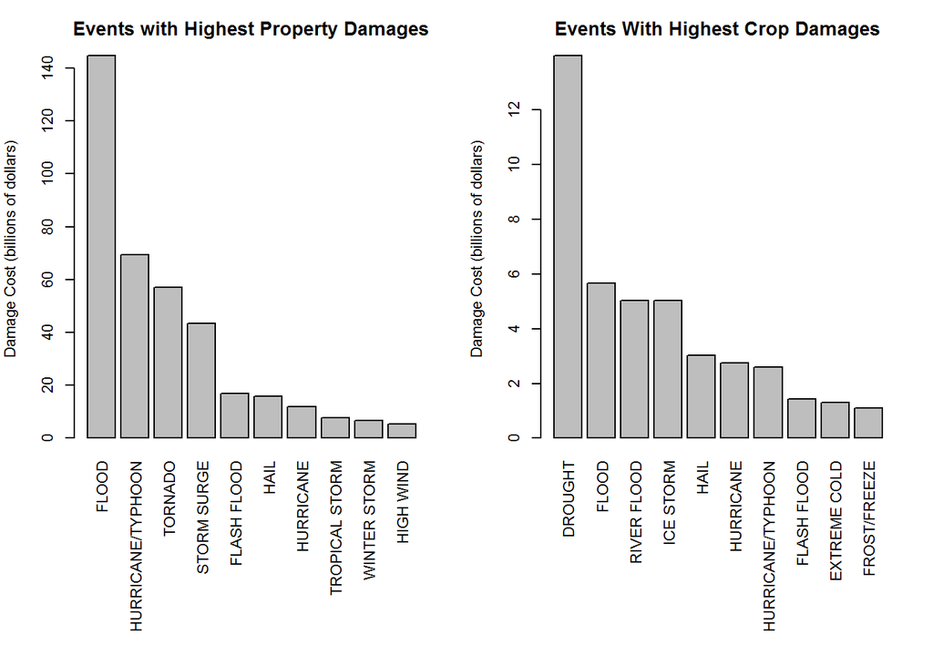

```r
propdmg <- propdmg[order(-propdmg$PROPVALUE),][1:10,]
cropdmg <- cropdmg[order(-cropdmg$CROPVALUE),][1:10,]
par(mfrow = c(1, 2), mar = c(12, 4, 3, 2), mgp = c(3, 1, 0), cex = 0.7)
barplot(propdmg$PROPVALUE/(10^9), las = 3, names.arg = propdmg$EVTYPE,
        main = "Events with Highest Property Damages", ylab = "Damage Cost (billions of dollars)")
barplot(cropdmg$CROPVALUE/(10^9), las = 3, names.arg = cropdmg$EVTYPE,
        main = "Events With Highest Crop Damages", ylab = "Damage Cost (billions of dollars)")
```

### Results

*Across the United States, which types of events (as indicated in the EVTYPE variable) are most harmful with respect to population health?*

TORNADO is most harmful. EXCESSIVE HEAT is second for fatalities and TSTM WIND is second for injuries

*Across the United States, which types of events have the greatest economic consequences?*

FLOOD followed by HURRICANE/TYPHOON is highest for Property Damage and DROUGHT followed by FLOOD is highest for crop damage.